# Introduction to R

**Things to check if it doesn’t work**

- Did you leave a hanging plus + at the end of the code? If so, remove it.
- Did you write *ggplot2()* instead of *ggplot()*?
- Did you remember to assign the x and y axes within the *aes()* function?
- Did you put a pipe %>% instead of a plus +?
- Did you misspell anything?
- Did you type out “cylinders” instead of using “cyl”? R doesn’t know those are related.
- Did you add a capital letter somewhere?
- Did you hit *enter* instead of *ctrl-enter*?
- Is there a space in the arrow < - or the pipes % >%? There shouldn’t be.
- Did you put the package in quotes when calling the *library()* function?
- Did you load the library *library(tidyverse)*? The pipes %>% only work if the tidyverse package is loaded.

**Challenges**

- Assign a different y variable
- Change the shape
- In addition to shape, make the colors green (HINT: see the cheatsheet)

**5) Added a mean and standard deviation to the plot.**

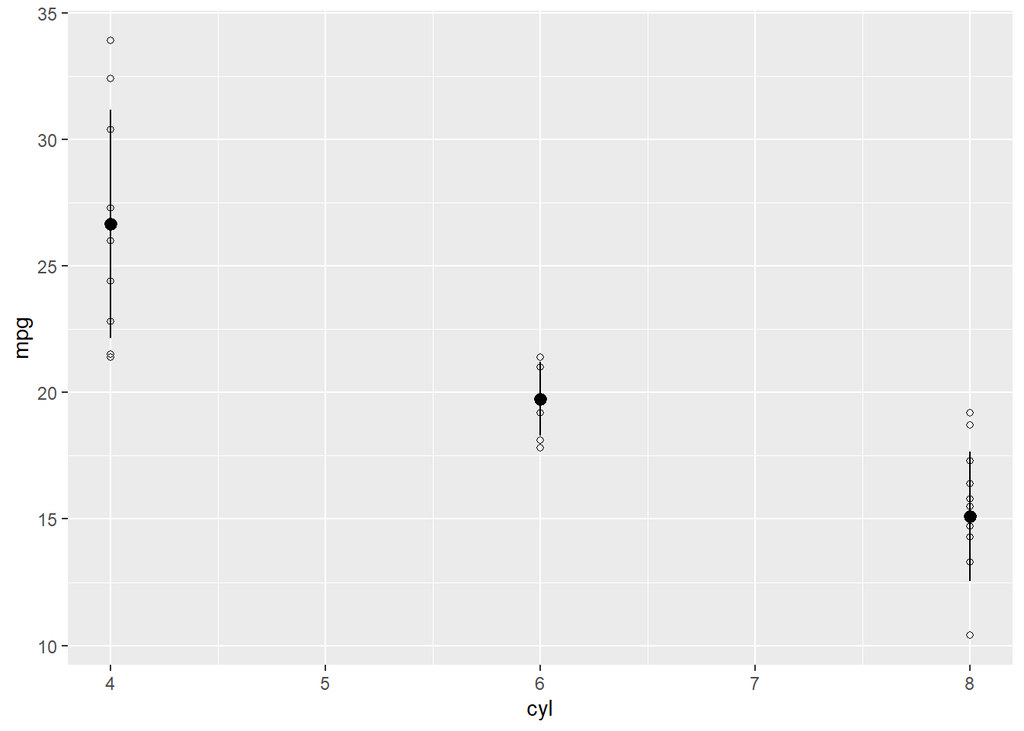

```r
#Copy this code, paste it in your script, and run it.
#load a package
library(tidyverse)

# make the data and "model" the mean and sd
d <- mtcars %>%
  group_by(cyl) %>%
  mutate(mean = mean(mpg), sd = sd(mpg))

#plot the data
ggplot(data = d, aes(x = cyl,y = mpg)) +
  geom_point(shape = 21) +
  geom_pointrange(aes(y = mean, ymin = mean-sd, ymax = mean+sd))
```

**What it does** The new geom *geom_pointrange()* adds the mean and standard deviation to the plot. If we only typed *geom_pointrange()*, it wouldn’t work. That’s because the geom requires three values that we haven’t assigned yet: y, ymin, and ymax. In this case, we want y to be the mean of each group. We want the error bar to range from ymin to ymax. ymin is the mean minus the standard deviation for each group *mean-sd*. ymax is the mean plus the standard deviation *mean+sd*. With those values, ggplot draws a line from ymin to ymax.

**Did it work?** The plot above should appear in the plot window (lower right).

**Things to check if it doesn’t work**

- Did you leave a hanging plus + at the end of the code? If so, remove it.
- Did you write *ggplot2()* instead of *ggplot()*?
- Did you remember to assign the x and y axes within the *aes()* function?
- Did you put a pipe %>% instead of a plus +?
- Did you misspell anything?
- Did you type out “cylinders” instead of using “cyl”? R doesn’t know those are related.
- Did you add a capital letter somewhere?
- Did you hit *enter* instead of *ctrl-enter*?
- Is there a space in the arrow < - or the pipes % >%? There shouldn’t be.
- Did you put the package in quotes when calling the *library()* function?
- Did you load the library *library(tidyverse)*? The pipes %>% only work if the tidyverse package is loaded.

**6) Modified the axis names.**

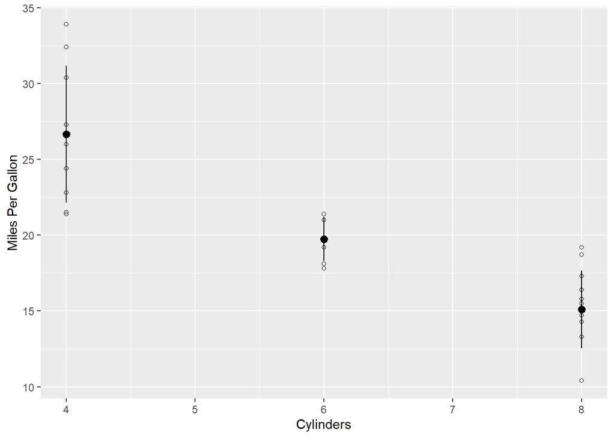

```r
#Copy this code, paste it in your script, and run it.
#load a package
library(tidyverse)

# make the data and "model" the mean and sd
d <- mtcars %>%
  group_by(cyl) %>%
  mutate(mean = mean(mpg), sd = sd(mpg))

#plot the data
ggplot(data = d, aes(x = cyl,y = mpg)) +
  geom_point(shape = 21) +
  geom_pointrange(aes(y = mean, ymin = mean-sd, ymax = mean+sd)) +
  labs(y = "Miles Per Gallon",
       x = "Cylinders")
```

**What it does** The function *labs()* replaces the title of the x and y axis with whatever we put in quotes.

**Did it work?** The plot above should appear in the plot window (lower right).

**Things to check if it doesn’t work**

- Did you remember the comma?
- Did you switch the x and y?
- Did you leave a hanging plus + at the end of the code? If so, remove it.
- Did you write *ggplot2()* instead of *ggplot()*?
- Did you remember to assign the x and y axes within the *aes()* function?
- Did you put a pipe %>% instead of a plus +?
- Did you misspell anything?
- Did you type out “cylinders” instead of using “cyl”? R doesn’t know those are related.
- Did you add a capital letter somewhere?
- Did you hit *enter* instead of *ctrl-enter*?
- Is there a space in the arrow < - or the pipes % >%? There shouldn’t be.
- Did you put the package in quotes when calling the *library()* function?
- Did you load the library *library(tidyverse)*? The pipes %>% only work if the tidyverse package is loaded.

**Challenges**

- Rename the x and y axes
- Add a title within the *labs()* function using *title = “put your title here”*

### Importing your own data to RStudio

To get your own data into R, first save the data into the same folder as your project.

Look in the lower right panel of RStudio. Click on “Files”. Do you see the dataset you saved? Click on it and choose *Import Dataset*.

Like this:

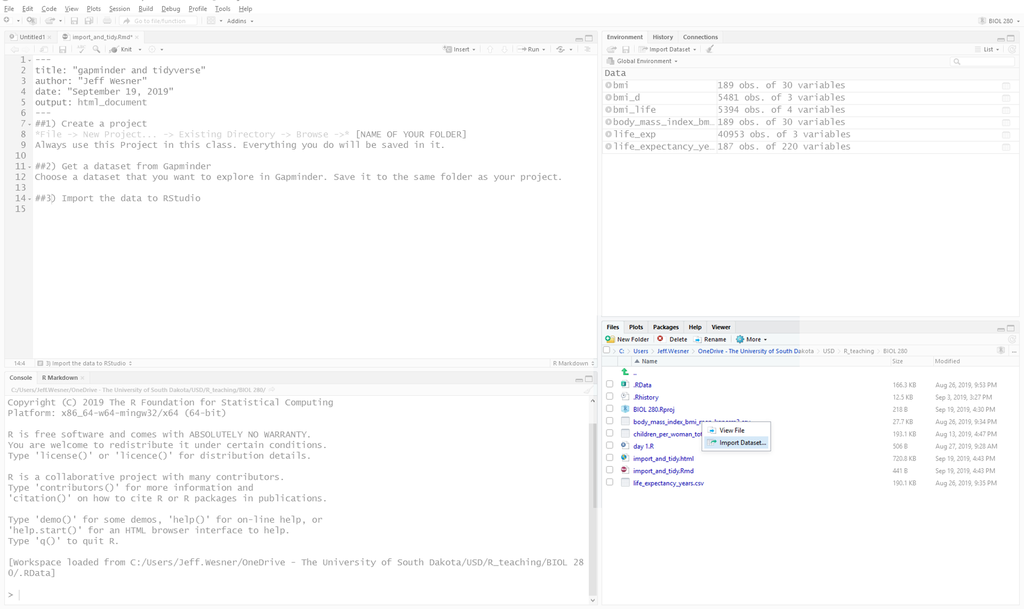

After you click *Import Dataset*, you’ll see a preview of your dataset like this:

[figure not shown]

Stop here and check the preview. Does everything look right? Are the column names correct? If not, you might need to check the box for “First Rows as Names” on the lower left.

From here, you have two options. 1) Click “Import”, or 2) Copy the code in the Preview Code box, cancel the preview, and paste the code into your script. We strongly recommend the second option.

Clicking will work, but if you come back to your script and need to reload the data, you’ll have to do this process again. If you instead copy the code and paste it into your script, then your code becomes self-contained and you won’t forget any steps in the future.

Here is where you can copy from. We don’t copy the *View()* part, but you can if you want:

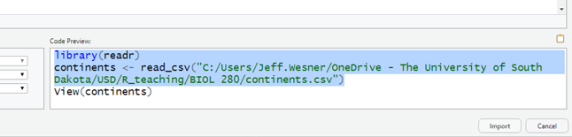

Then paste it at the beginning of your script and run it.

[figure not shown]

Do you see the name of your dataset in the upper right panel? If so, success! If not, re-try the steps above or ask your instructor. You are now ready to practice the coding you’ve learned on your own dataset.

## Why to Code Instead of Click

R is a programming language, which means that it can only do what you tell it to do by typing. RStudio has a few clickable shortcuts, but it still requires nearly everything to be typed into a script.

There are other programs that conduct statistical and graphical analyses without using code. We choose to use R instead for several reasons.

**Clicking isn’t Actually Easier**

Undergraduates are incredibly savvy with some aspects of computers, particularly in nagivating social media platforms. But in our experience, students often struggle with even rudimentary tasks in programs that professors think are easy, such as Microsoft Excel or SPSS. These programs have their own bewildering array of shortcuts and buttons [@nash_teaching_2008]. For example, while this Excel function might make perfect sense to a seasoned user

=STDEV.P(A$1:A$7)

it can be just as confusing to a new student as the similar function in R “*sd(*data$column*)*”.

Similarly, while it may seem easier to run an ANOVA in SPSS by simply clicking the ANOVA button, this too is often misleading. Having helped students that are partway through a project in SPSS or other clickable programs, we almost always have to start their entire analysis over when a problem arises. The reason is that, by the time the ANOVA button is clicked, there have already been a series of steps in data preparation and uploading that might have generated a problem. In R, we can find these problems easily, because the script leaves a breadcrumb trail of each step. In non-scripting programs, there are no breadcrumbs, so solving the problem becomes much more complicated. And not matter what program you use or how simple your dataset seems, there will definitely be problems to solve.

**Data Ethics**

A basic requirement in modern science is that the results of scientific findings could be reproduced by someone else. There are two levels to this. The first level is the description of the experimental approach, which is contained in a Methods section in a scientific publication. This ensures that someone else could read a Methods section and reproduce the steps of the experiment exactly without having to ask the author (who may no longer be alive or just doesn’t respond to email).

The second level of reproducibility is in the analysis of a dataset presented in a scientific publication. All analyses involve myriad human decisions. For example, what do we do with outliers (extreme data values that may be real or may be a result of data entry error or errors in the instruments)? What if half of our fish died in the middle of an experiment? Should we replace them with new ones? There are no easy answers to these questions. Each experiment has its own quirks and they will all involve subjective decisions by the scientist.

What do we do about these subjective decisions? The golden rule is to be transparent about them in two ways. First, describe them in the Methods and provide a justification for them. Second, always include a way for readers to easily find the raw data and any scripts. This is where using computer code over clicking makes a huge difference. If the raw data and script are available, then it is simple for someone else to run the analysis later and see the decisions you made about the data quirks. Different scientists will make different decisions about each of those quirks. The most important thing is not which decision is made per se, but that the trail of breadcrumbs exists to *allow* a decision to be transparent.

That may seem a little daunting. It is scary to have someone else see all of your decisions. But here’s the actual truth: The person who will benefit most from your transparent data and code is not another scientist. It is you. In two days, two months, or two years, you will eventually have to return to an old analysis. You’ll need it to wrap up that semester’s term paper or to reanalyze something from your thesis. You will NOT NOT NOT NOT NOT remember what you have done, no matter how obvious it seemed when you were doing it. For that reason, having script that is reproducible will save you hours, maybe weeks, of otherwise wasted time. Trust us…just trust us.

[^1]: Except for JR, an English professor who doesn’t understand any of this. We assume he is currently pontificating about the literary importance of using *salve* versus *halve* in the writings of Chaucer (who uses neither word). JR has a large collection of feathered pens and prefers to write on low gloss paper sourced from the Pacific Northeast.